# 05_RQ5_survival_analysis

### Stratified by responder/non responder

```r
df_r <- clean_clinical_TMB |>
  filter(Responder_Group == "R")

cut_tmb_r <- surv_cutpoint(
  data = df_r,
  time = "os",
  event = "censOS",
  variables = "FMOne.mutation.burden.per.MB",
  minprop = 0.1
)

summary(cut_tmb_r)
```

|  | cutpoint | statistic |
| --- | --- | --- |
| FMOne.mutation.burden.per.MB | 6 | 1.733841 |

```r
png(
  filename = file.path(results_dir, "RQ5_cutpoint_TMB_responders.png"),
  width = 7,
  height = 5,
  units = "in",
  res = 300
)
plot(cut_tmb_r, "FMOne.mutation.burden.per.MB", palette = "npg")
```

```r
dev.off()
```

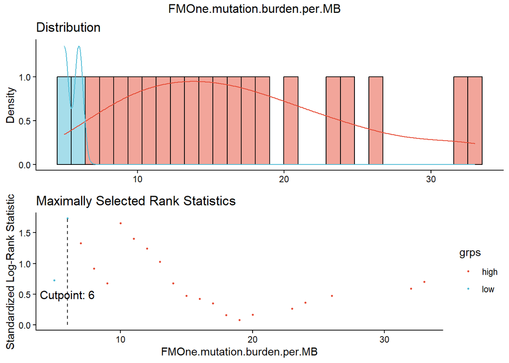

```r
plot(cut_tmb_r, "FMOne.mutation.burden.per.MB", palette = "npg")
```

```r
cat_tmb_r <- surv_categorize(cut_tmb_r)

df_r <- df_r |>
  mutate(TMB_Cutpoint_Group = cat_tmb_r$FMOne.mutation.burden.per.MB)
```

```r
df_nr <- clean_clinical_TMB |>
  filter(Responder_Group == "NR")

cut_tmb_nr <- surv_cutpoint(
  data = df_nr,
  time = "os",
  event = "censOS",
  variables = "FMOne.mutation.burden.per.MB",
  minprop = 0.1
)

summary(cut_tmb_nr)
```

|  | cutpoint | statistic |
| --- | --- | --- |
| FMOne.mutation.burden.per.MB | 15 | 1.078865 |

```r
png(
  filename = file.path(results_dir, "RQ5_cutpoint_TMB_nonresponders.png"),
  width = 7,
  height = 5,
  units = "in",
  res = 300
)
plot(cut_tmb_nr, "FMOne.mutation.burden.per.MB", palette = "npg")
```

```r
dev.off()
```

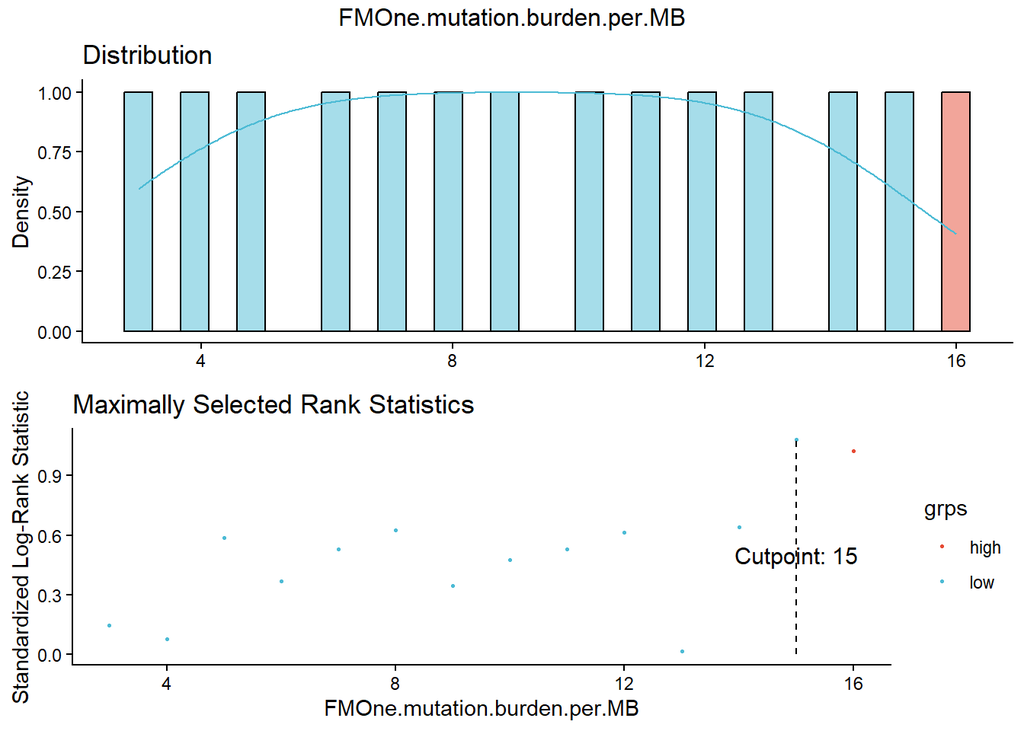

```r
plot(cut_tmb_nr, "FMOne.mutation.burden.per.MB", palette = "npg")
```

```r
cat_tmb_nr <- surv_categorize(cut_tmb_nr)

df_nr <- df_nr |>
  mutate(TMB_Cutpoint_Group = cat_tmb_nr$FMOne.mutation.burden.per.MB)
```

```r
table(df_r$TMB_Cutpoint_Group)
```

```
high  low
  50   11
```

```r
table(df_nr$TMB_Cutpoint_Group)
```

```
high  low
  21  152
```

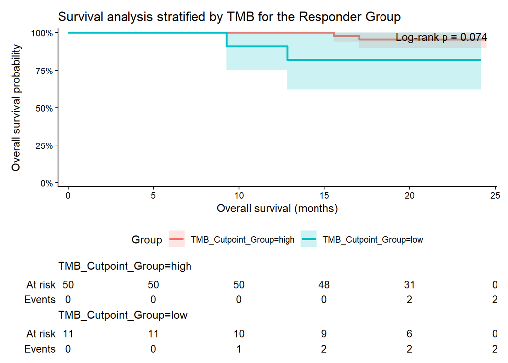

```r
fit_tmb_r <- survfit(Surv(os, censOS) ~ TMB_Cutpoint_Group,
                   data = df_r)
lr_tmb_r <- survdiff(Surv(os, censOS) ~ TMB_Cutpoint_Group,
                   data = df_r)

p_km_tmb_r <- km_plot(
  fit_tmb_r,
  "Survival analysis stratified by TMB for the Responder Group",
  lr_p(lr_tmb_r)
)

print(p_km_tmb_r)
```

```r
ggsave(
  filename = file.path(results_dir, "RQ5_km_survival_TMB_responders.png"),
  plot = p_km_tmb_r,
  width = 7,
  height = 6,
  dpi = 300
)
```

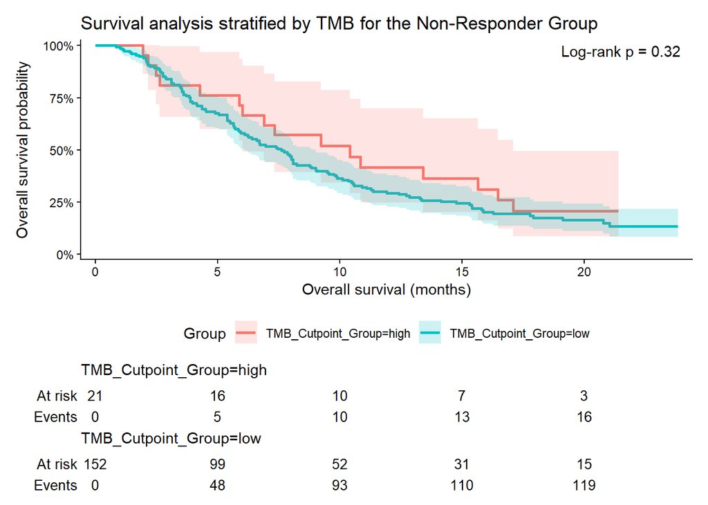

```r
fit_tmb_nr <- survfit(Surv(os, censOS) ~ TMB_Cutpoint_Group,
                     data = df_nr)
lr_tmb_nr <- survdiff(Surv(os, censOS) ~ TMB_Cutpoint_Group,
                     data = df_nr)

p_km_tmb_nr <- km_plot(
  fit_tmb_nr,
  "Survival analysis stratified by TMB for the Non-Responder Group",
  lr_p(lr_tmb_nr)
)

print(p_km_tmb_nr)
```

```r
ggsave(
  filename = file.path(results_dir, "RQ5_km_survival_TMB_nonresponders.png"),
  plot = p_km_tmb_nr,
  width = 7,
  height = 6,
  dpi = 300
)
```

```r
table(df_nr$Best.Confirmed.Overall.Response, df_nr$TMB_Cutpoint_Group)
```

```
     high low
  CR    0   0
  PR    0   0
  SD    6  38
  PD   15 114
  NE    0   0
```

### Hazard Ratio

```r
# Model TMB continuously; one unit is one doubling of TMB
cox_tmb <- coxph(
  Surv(os, censOS) ~ log2(FMOne.mutation.burden.per.MB+1),
  data = clean_clinical_TMB
)

# Display the hazard ratio and 95% confidence interval
exp(cbind(
  HR = coef(cox_tmb),
  confint(cox_tmb)
))
```

```
                                              HR     2.5 %    97.5 %
log2(FMOne.mutation.burden.per.MB + 1) 0.7490385 0.6403906 0.8761194
```

```r
# Display the complete Cox-model result
summary(cox_tmb)
```

```
Call:
coxph(formula = Surv(os, censOS) ~ log2(FMOne.mutation.burden.per.MB +
    1), data = clean_clinical_TMB)

  n= 234, number of events= 141

                                           coef exp(coef) se(coef)      z
log2(FMOne.mutation.burden.per.MB + 1) -0.28896   0.74904  0.07996 -3.614
                                       Pr(>|z|)
log2(FMOne.mutation.burden.per.MB + 1) 0.000301 ***
---
Signif. codes:  0 '***' 0.001 '**' 0.01 '*' 0.05 '.' 0.1 ' ' 1

                                       exp(coef) exp(-coef) lower .95 upper .95
log2(FMOne.mutation.burden.per.MB + 1)     0.749      1.335    0.6404    0.8761

Concordance= 0.586  (se = 0.025 )
Likelihood ratio test= 12.92  on 1 df,   p=3e-04
Wald test            = 13.06  on 1 df,   p=3e-04
Score (logrank) test = 13.02  on 1 df,   p=3e-04
```

```r
# Check the proportional-hazards assumption
ph_tmb <- cox.zph(cox_tmb)
ph_tmb
```

```
                                       chisq df    p
log2(FMOne.mutation.burden.per.MB + 1) 0.787  1 0.38
GLOBAL                                 0.787  1 0.38
```

A continuous Cox proportional hazards model on $\log_2(\text{TMB} + 1)$ shows that higher Tumor Mutational Burden is significantly associated with a lower hazard of death for the whole cohort and therefore better overall survival ($\text{HR} = 0.75$, 95% CI: $0.64\text{-}0.88$). The proportional hazards assumption is not violated ($p = 0.38$), supporting a consistent protective association across follow-up time and reinforcing our Kaplan-Meier findings without relying on a single cutoff.

```r
# Model TMB continuously; one unit is one doubling of TMB
cox_tmb_r <- coxph(
  Surv(os, censOS) ~ log2(FMOne.mutation.burden.per.MB+1),
  data = df_r
)

# Display the hazard ratio and 95% confidence interval
exp(cbind(
  HR = coef(cox_tmb_r),
  confint(cox_tmb_r)
))
```

```
                                              HR     2.5 %   97.5 %
log2(FMOne.mutation.burden.per.MB + 1) 0.8344856 0.3217412 2.164367
```

```r
cox.zph(cox_tmb_r)
```

```
                                       chisq df     p
log2(FMOne.mutation.burden.per.MB + 1)   4.3  1 0.038
GLOBAL                                   4.3  1 0.038
```

```r
# Model TMB continuously; one unit is one doubling of TMB
cox_tmb_nr <- coxph(
  Surv(os, censOS) ~ log2(FMOne.mutation.burden.per.MB+1),
  data = df_nr
)

# Display the hazard ratio and 95% confidence interval
exp(cbind(
  HR = coef(cox_tmb_nr),
  confint(cox_tmb_nr)
))
```

```
                                             HR     2.5 %   97.5 %
log2(FMOne.mutation.burden.per.MB + 1) 1.006349 0.8394353 1.206453
```

```r
cox.zph(cox_tmb_nr)
```

```
                                       chisq df   p
log2(FMOne.mutation.burden.per.MB + 1)  0.15  1 0.7
GLOBAL                                  0.15  1 0.7
```

However, when fitting the continuous Cox model separately within responders (`df_r`) and non-responders (`df_nr`), the 95% confidence intervals include $1$ in both subsets. This indicates no statistically significant continuous association between $\log_2(\text{TMB} + 1)$ and overall survival within either response group alone, likely reflecting the small sample sizes and event counts per subgroup (as well as reduced contrast once stratified by response status), and therefore warrants cautious, exploratory interpretation rather than a definitive within-group conclusion.

Within responders ($n = 61$: 50 high-TMB and 11 low-TMB), only 4 events occurred in total (2 per group), with the two events in the low-TMB group appearing earlier than the two events in the high-TMB group. Because event counts are so sparse - and the 95% CI already spans $1$ - the proportional hazards test (`cox.zph` $p = 0.038$) should be interpreted cautiously as a sign that the subgroup model is underpowered/unstable rather than a robust standalone finding.

```r
zph_tmb_r <- cox.zph(cox_tmb_r)
print(zph_tmb_r)
```

```
                                       chisq df     p
log2(FMOne.mutation.burden.per.MB + 1)   4.3  1 0.038
GLOBAL                                   4.3  1 0.038
```

```r
png(
  filename = file.path(results_dir, "RQ5_zph_TMB_responders.png"),
  width = 7,
  height = 5,
  units = "in",
  res = 300
)
plot(zph_tmb_r)
dev.off()
```

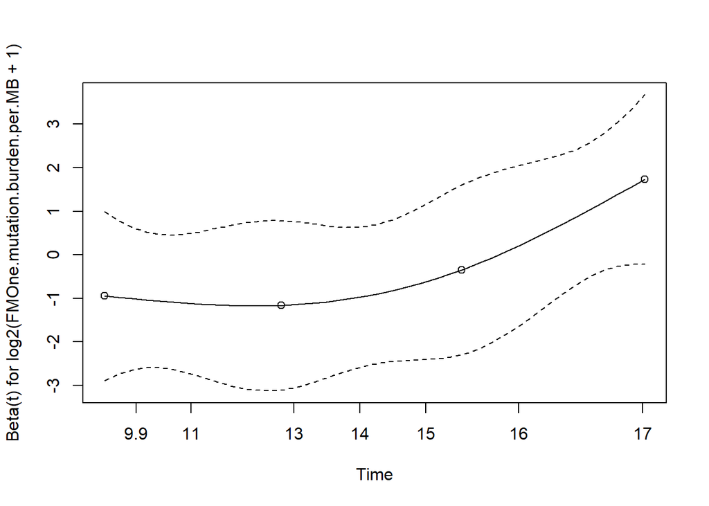

```r
plot(zph_tmb_r)
```

## TNB Survival Analysis

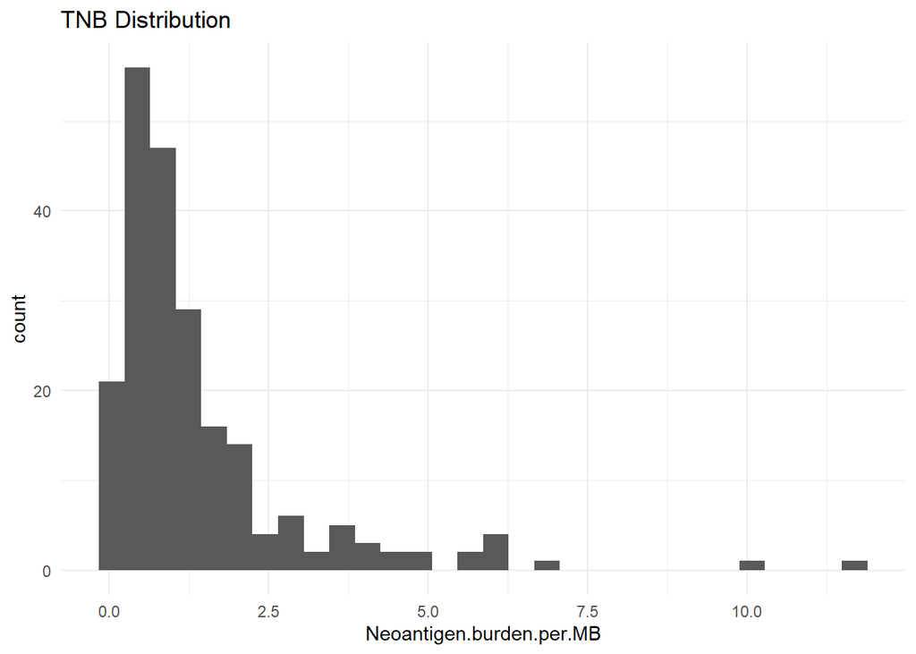

```r
p_tnb_dist <- ggplot(
  clean_clinical_TNB,
  aes(x = Neoantigen.burden.per.MB)
) +
  geom_histogram() +
  theme_minimal() +
  labs(title = "TNB Distribution")

print(p_tnb_dist)
```

```r
ggsave(
  filename = file.path(results_dir, "RQ5_distribution_TNB.png"),
  plot = p_tnb_dist,
  width = 7,
  height = 5,
  dpi = 300
)
```

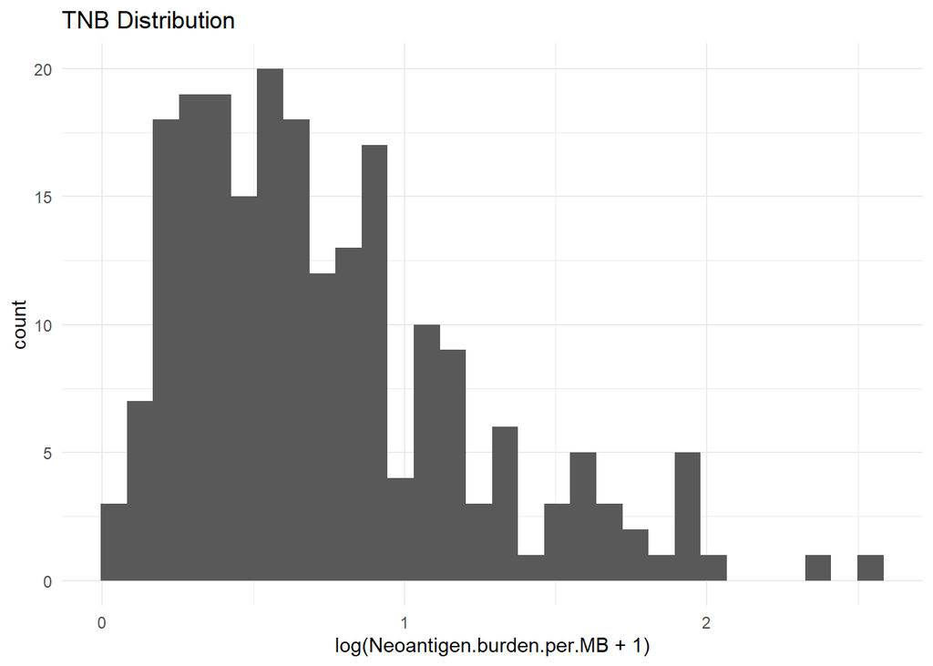

```r
p_tnb_log_dist <- ggplot(
  clean_clinical_TNB,
  aes(x = log(Neoantigen.burden.per.MB + 1))
) +
  geom_histogram() +
  theme_minimal() +
  labs(title = "TNB Distribution")

print(p_tnb_log_dist)
```

```r
ggsave(
  filename = file.path(results_dir, "RQ5_distribution_TNB_log.png"),
  plot = p_tnb_log_dist,
  width = 7,
  height = 5,
  dpi = 300
)
```

### Whole cohort

```r
# Find the optimal cutpoint for TNB against overall survival
cut_tnb <- surv_cutpoint(
  data = clean_clinical_TNB,
  time = "os",
  event = "censOS",
  variables = "Neoantigen.burden.per.MB",
  minprop = 0.1
)

summary(cut_tnb)
```

|  | cutpoint | statistic |
| --- | --- | --- |
| Neoantigen.burden.per.MB | 1.470588 | 5.181097 |

```r
png(
  filename = file.path(results_dir, "RQ5_cutpoint_TNB.png"),
  width = 7,
  height = 5,
  units = "in",
  res = 300
)
plot(cut_tnb, "Neoantigen.burden.per.MB", palette = "npg")
```

```r
dev.off()
```

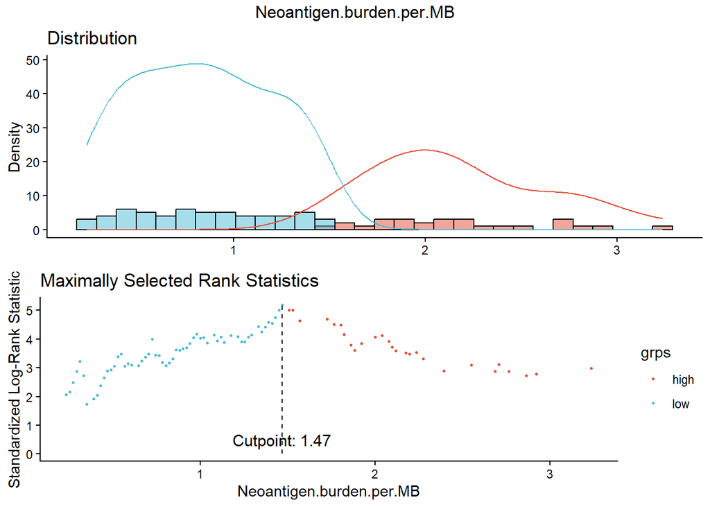

```r
plot(cut_tnb, "Neoantigen.burden.per.MB", palette = "npg")
```

```r
# Categorize patients into High vs. Low TNB using the cutpoint
cat_tnb <- surv_categorize(cut_tnb)
```

```r
# Add the new factor column back to your clinical data frame
clean_clinical_TNB <- clean_clinical_TNB |>
  mutate(TNB_Cutpoint_Group = cat_tnb$Neoantigen.burden.per.MB)

table(clean_clinical_TNB$TNB_Cutpoint_Group)
```

```
high  low
  60  156
```

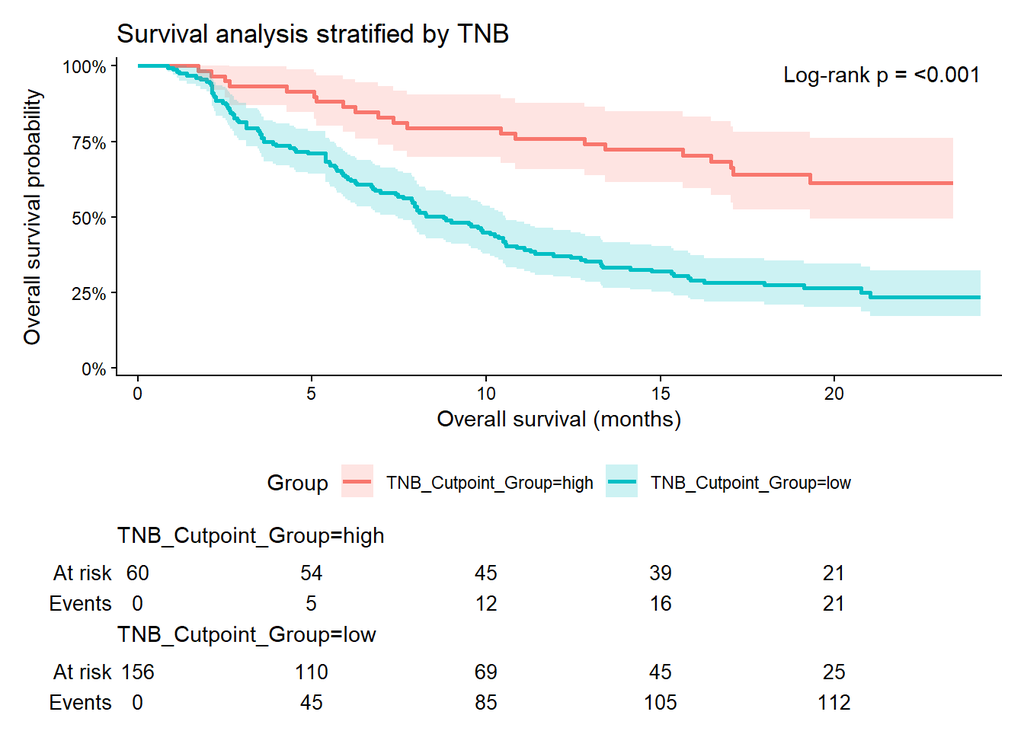

```r
fit_tnb <- survfit(Surv(os, censOS) ~ TNB_Cutpoint_Group,
                   data = clean_clinical_TNB)
lr_tnb <- survdiff(Surv(os, censOS) ~ TNB_Cutpoint_Group,
                   data = clean_clinical_TNB)

p_km_tnb <- km_plot(
  fit_tnb,
  "Survival analysis stratified by TNB",
  lr_p(lr_tnb)
)

print(p_km_tnb)
```

```r
ggsave(
  filename = file.path(results_dir, "RQ5_km_survival_TNB.png"),
  plot = p_km_tnb,
  width = 7,
  height = 6,
  dpi = 300
)
```

### Stratified by responder/non responder

```r
df_tnb_r <- clean_clinical_TNB |>
  filter(Responder_Group == "R")

cut_tnb_r <- surv_cutpoint(
  data = df_tnb_r,
  time = "os",
  event = "censOS",
  variables = "Neoantigen.burden.per.MB",
  minprop = 0.1
)

summary(cut_tnb_r)
```

|  | cutpoint | statistic |
| --- | --- | --- |
| Neoantigen.burden.per.MB | 0.8431373 | 0.9344127 |

```r
png(
  filename = file.path(results_dir, "RQ5_cutpoint_TNB_responders.png"),
  width = 7,
  height = 5,
  units = "in",
  res = 300
)
plot(cut_tnb_r, "Neoantigen.burden.per.MB", palette = "npg")
```

```r
dev.off()
```

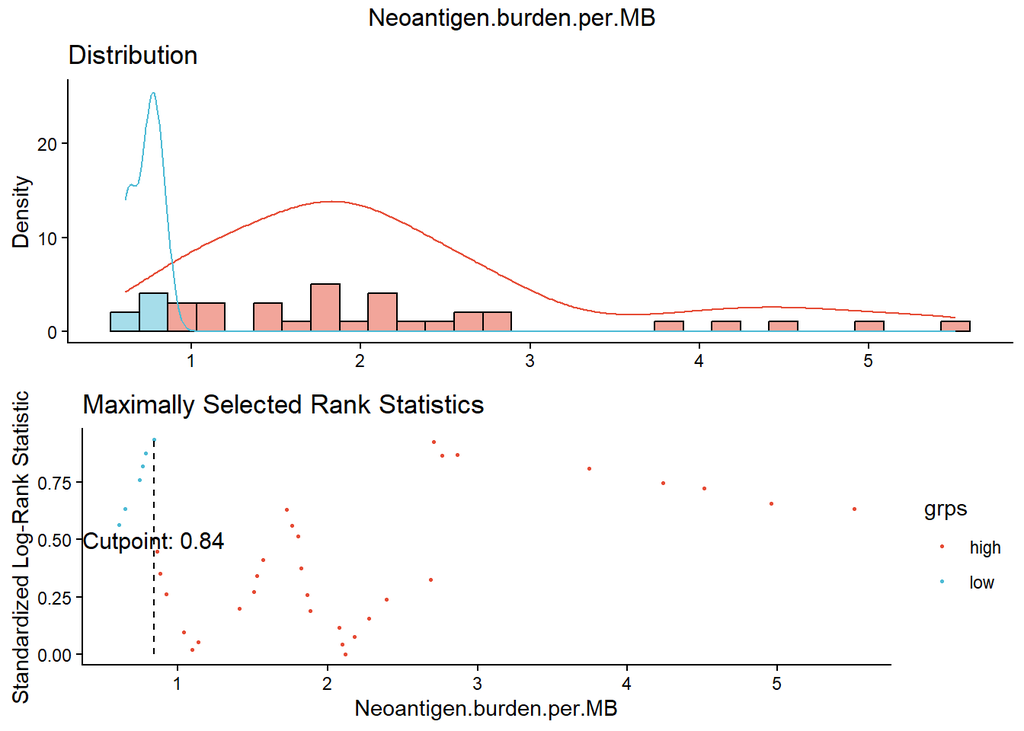

```r
plot(cut_tnb_r, "Neoantigen.burden.per.MB", palette = "npg")
```

```r
cat_tnb_r <- surv_categorize(cut_tnb_r)

df_tnb_r <- df_tnb_r |>
  mutate(TNB_Cutpoint_Group = cat_tnb_r$Neoantigen.burden.per.MB)
```

```r
df_tnb_nr <- clean_clinical_TNB |>
  filter(Responder_Group == "NR")

cut_tnb_nr <- surv_cutpoint(
  data = df_tnb_nr,
  time = "os",
  event = "censOS",
  variables = "Neoantigen.burden.per.MB",
  minprop = 0.1
)

summary(cut_tnb_nr)
```

|  | cutpoint | statistic |
| --- | --- | --- |
| Neoantigen.burden.per.MB | 2 | 1.855243 |

```r
png(
  filename = file.path(results_dir, "RQ5_cutpoint_TNB_nonresponders.png"),
  width = 7,
  height = 5,
  units = "in",
  res = 300
)
plot(cut_tnb_nr, "Neoantigen.burden.per.MB", palette = "npg")
```

```r
dev.off()
```

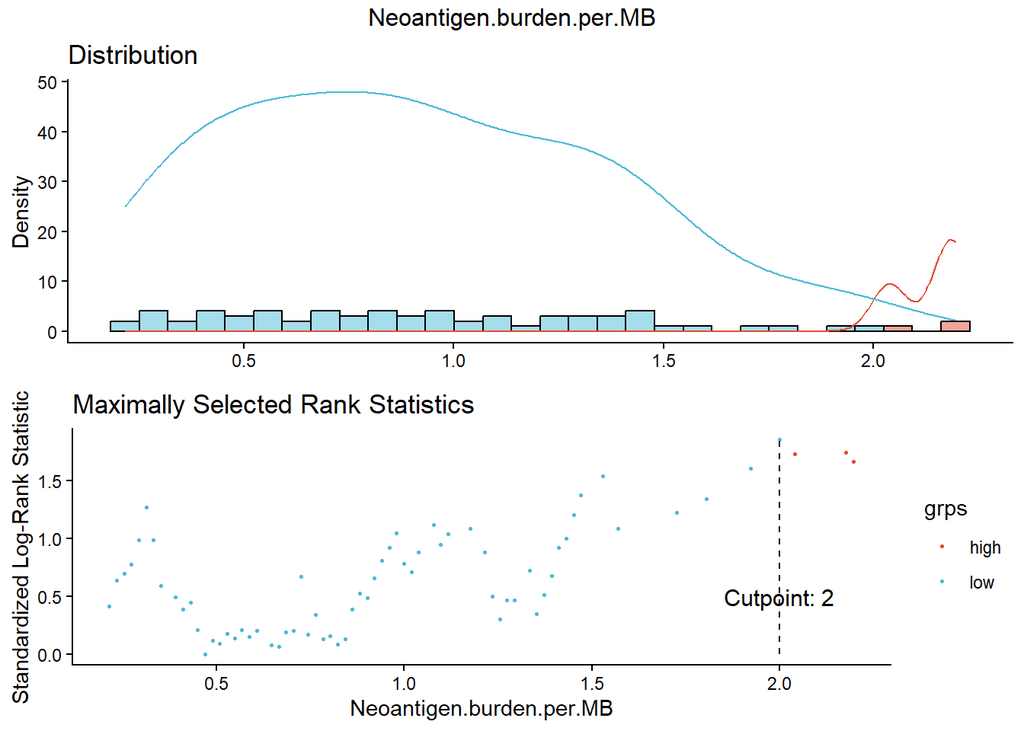

```r
plot(cut_tnb_nr, "Neoantigen.burden.per.MB", palette = "npg")
```

```r
cat_tnb_nr <- surv_categorize(cut_tnb_nr)

df_tnb_nr <- df_tnb_nr |>
  mutate(TNB_Cutpoint_Group = cat_tnb_nr$Neoantigen.burden.per.MB)
```

```r
table(df_tnb_r$TNB_Cutpoint_Group)
```

```
high  low
  42   11
```

```r
table(df_tnb_nr$TNB_Cutpoint_Group)
```

```
high  low
  21  142
```

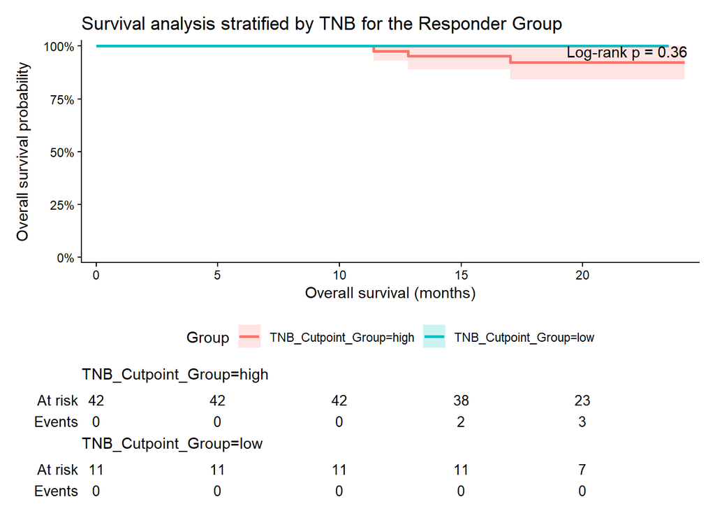

```r
fit_tnb_r <- survfit(Surv(os, censOS) ~ TNB_Cutpoint_Group,
                   data = df_tnb_r)
lr_tnb_r <- survdiff(Surv(os, censOS) ~ TNB_Cutpoint_Group,
                   data = df_tnb_r)

p_km_tnb_r <- km_plot(
  fit_tnb_r,
  "Survival analysis stratified by TNB for the Responder Group",
  lr_p(lr_tnb_r)
)

print(p_km_tnb_r)
```

```r
ggsave(
  filename = file.path(results_dir, "RQ5_km_survival_TNB_responders.png"),
  plot = p_km_tnb_r,
  width = 7,
  height = 6,
  dpi = 300
)
```

```r
table(df_tnb_r$Best.Confirmed.Overall.Response, df_tnb_r$TNB_Cutpoint_Group)
```

```
     high low
  CR   14   5
  PR   28   6
  SD    0   0
  PD    0   0
  NE    0   0
```

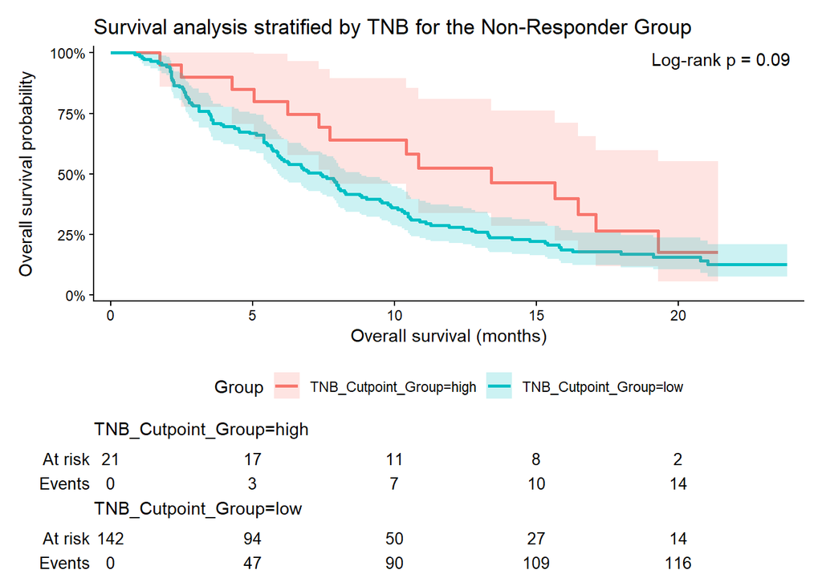

```r
fit_tnb_nr <- survfit(Surv(os, censOS) ~ TNB_Cutpoint_Group,
                     data = df_tnb_nr)
lr_tnb_nr <- survdiff(Surv(os, censOS) ~ TNB_Cutpoint_Group,
                     data = df_tnb_nr)

p_km_tnb_nr <- km_plot(
  fit_tnb_nr,
  "Survival analysis stratified by TNB for the Non-Responder Group",
  lr_p(lr_tnb_nr)
)

print(p_km_tnb_nr)
```

```r
ggsave(
  filename = file.path(results_dir, "RQ5_km_survival_TNB_nonresponders.png"),
  plot = p_km_tnb_nr,
  width = 7,
  height = 6,
  dpi = 300
)
```

```r
table(df_tnb_nr$Best.Confirmed.Overall.Response, df_tnb_nr$TNB_Cutpoint_Group)
```

```
     high low
  CR    0   0
  PR    0   0
  SD    5  39
  PD   16 103
  NE    0   0
```

### Hazard Ratio

```r
# Model TMB continuously; one unit is one doubling of TMB
cox_tnb <- coxph(
  Surv(os, censOS) ~ log2(Neoantigen.burden.per.MB+1),
  data = clean_clinical_TNB
)

# Display the hazard ratio and 95% confidence interval
exp(cbind(
  HR = coef(cox_tnb),
  confint(cox_tnb)
))
```

```
                                          HR     2.5 %    97.5 %
log2(Neoantigen.burden.per.MB + 1) 0.5165301 0.3872169 0.6890281
```

```r
# Display the complete Cox-model result
summary(cox_tnb)
```

```
Call:
coxph(formula = Surv(os, censOS) ~ log2(Neoantigen.burden.per.MB +
    1), data = clean_clinical_TNB)

  n= 216, number of events= 135

                                      coef exp(coef) se(coef)      z Pr(>|z|)
log2(Neoantigen.burden.per.MB + 1) -0.6606    0.5165   0.1470 -4.493 7.01e-06

log2(Neoantigen.burden.per.MB + 1) ***
---
Signif. codes:  0 '***' 0.001 '**' 0.01 '*' 0.05 '.' 0.1 ' ' 1

                                   exp(coef) exp(-coef) lower .95 upper .95
log2(Neoantigen.burden.per.MB + 1)    0.5165      1.936    0.3872     0.689

Concordance= 0.606  (se = 0.024 )
Likelihood ratio test= 23.98  on 1 df,   p=1e-06
Wald test            = 20.19  on 1 df,   p=7e-06
Score (logrank) test = 20.69  on 1 df,   p=5e-06
```

```r
# Check the proportional-hazards assumption
ph_tnb <- cox.zph(cox_tnb)
ph_tnb
```

```
                                   chisq df    p
log2(Neoantigen.burden.per.MB + 1) 0.398  1 0.53
GLOBAL                             0.398  1 0.53
```

A continuous Cox proportional hazards model on $\log_2(\text{TNB} + 1)$ shows that higher neoantigen burden is associated with a substantially lower hazard of death and better overall survival ($\text{HR} = 0.51$, 95% CI: $0.39\text{--}0.69$), with no violation of the proportional hazards assumption ($p = 0.53$). While this points to a stronger per-unit protective association than observed for $\log_2(\text{TMB} + 1)$ ($\text{HR} = 0.75$), direct comparison should keep in mind differences in scale/transformation and cohort subsets between the TMB and TNB analyses.

```r
# Model TMB continuously; one unit is one doubling of TMB
cox_tnb_r <- coxph(
  Surv(os, censOS) ~ log2(Neoantigen.burden.per.MB+1),
  data = df_tnb_r
)

# Display the hazard ratio and 95% confidence interval
exp(cbind(
  HR = coef(cox_tnb_r),
  confint(cox_tnb_r)
))
```

```
                                         HR     2.5 %   97.5 %
log2(Neoantigen.burden.per.MB + 1) 0.780775 0.1558316 3.911975
```

```r
cox.zph(cox_tnb_r)
```

```
                                   chisq df    p
log2(Neoantigen.burden.per.MB + 1)  1.12  1 0.29
GLOBAL                              1.12  1 0.29
```

```r
# Model TMB continuously; one unit is one doubling of TMB
cox_tnb_nr <- coxph(
  Surv(os, censOS) ~ log2(Neoantigen.burden.per.MB+1),
  data = df_tnb_nr
)

# Display the hazard ratio and 95% confidence interval
exp(cbind(
  HR = coef(cox_tnb_nr),
  confint(cox_tnb_nr)
))
```

```
                                          HR     2.5 %   97.5 %
log2(Neoantigen.burden.per.MB + 1) 0.8518498 0.6398422 1.134105
```

```r
cox.zph(cox_tnb_nr)
```

```
                                    chisq df   p
log2(Neoantigen.burden.per.MB + 1) 0.0639  1 0.8
GLOBAL                             0.0639  1 0.8
```

The same pattern holds for neoantigen burden: when the continuous $\log_2(\text{TNB} + 1)$ Cox model is fit separately within responders and non-responders, the 95% confidence intervals again include $1$, underscoring that while overall survival benefits associate with higher burden across the cohort, smaller within-subgroup sample and event counts limit statistical precision within each response group alone.

## Shared Complete-Case Comparison (TMB vs. TNB)

Because `clean_clinical_TMB` and `clean_clinical_TNB` are filtered separately for missing values in each biomarker, their patient cohorts do not overlap completely. Here we isolate the shared complete-case subset with non-missing values for both `FMOne.mutation.burden.per.MB` and `Neoantigen.burden.per.MB` (as well as survival outcome variables) so we can compare the two continuous Cox models on the exact same patients.

```r
# Identify shared patients using row names with non-missing survival data
common_ids <- intersect(
  rownames(clean_clinical_TMB),
  rownames(clean_clinical_TNB)
)

df_shared <- clean_clinical_TMB[common_ids, , drop = FALSE] |>
  mutate(Neoantigen.burden.per.MB = clean_clinical_TNB[common_ids, "Neoantigen.burden.per.MB"]) |>
  filter(
    !is.na(FMOne.mutation.burden.per.MB),
    !is.na(Neoantigen.burden.per.MB),
    !is.na(os),
    !is.na(censOS)
  )

cat("Shared complete-case sample size (n):", nrow(df_shared), "\n")
```

```
Shared complete-case sample size (n): 192
```

```r
cat("Total OS events in shared subset:", sum(df_shared$censOS == 1, na.rm = TRUE), "\n")
```

```
Total OS events in shared subset: 115
```

```r
# Continuous Cox model for TMB on the shared subset
cox_shared_tmb <- coxph(
  Surv(os, censOS) ~ log2(FMOne.mutation.burden.per.MB + 1),
  data = df_shared
)

exp(cbind(
  HR = coef(cox_shared_tmb),
  confint(cox_shared_tmb)
))
```

```
                                              HR     2.5 %    97.5 %
log2(FMOne.mutation.burden.per.MB + 1) 0.7262897 0.6093844 0.8656223
```

```r
cox.zph(cox_shared_tmb)
```

```
                                       chisq df    p
log2(FMOne.mutation.burden.per.MB + 1) 0.918  1 0.34
GLOBAL                                 0.918  1 0.34
```

```r
# Continuous Cox model for TNB on the shared subset
cox_shared_tnb <- coxph(
  Surv(os, censOS) ~ log2(Neoantigen.burden.per.MB + 1),
  data = df_shared
)

exp(cbind(
  HR = coef(cox_shared_tnb),
  confint(cox_shared_tnb)
))
```

```
                                          HR     2.5 %   97.5 %
log2(Neoantigen.burden.per.MB + 1) 0.4838261 0.3504133 0.668033
```

```r
cox.zph(cox_shared_tnb)
```

```
                                     chisq df    p
log2(Neoantigen.burden.per.MB + 1) 0.00793  1 0.93
GLOBAL                             0.00793  1 0.93
```

Evaluating both continuous $\log_2(\text{burden} + 1)$ Cox models on the shared complete-case cohort removes differences in sample composition and event counts between the TMB and TNB analyses, allowing a more direct check of whether neoantigen burden shows a stronger protective association with overall survival than TMB on the same patients.

On the shared complete-case cohort, the protective association with overall survival persists for both $\log_2(\text{TNB} + 1)$ ($\text{HR} = 0.48$, 95% CI: $0.35\text{-}0.67$; `cox.zph` $p = 0.93$) and $\log_2(\text{TMB} + 1)$ ($\text{HR} = 0.73$, 95% CI: $0.61\text{-}0.87$; `cox.zph` $p = 0.34$). Because both models are evaluated on the exact same patients without violations of the proportional hazards assumption, this confirms that the stronger per-unit hazard reduction observed for neoantigen burden compared with TMB is not simply an artifact of differing sample subsets.

## Multivariable Cox Models Adjusting for Response

To test whether continuous $\log_2(\text{TMB} + 1)$ and $\log_2(\text{TNB} + 1)$ remain associated with overall survival after accounting for response status (`Responder_Group`), we fit multivariable Cox proportional hazards models without shrinking sample sizes by splitting into separate `R` and `NR` subsets.

```r
# Ensure Responder_Group is a factor with a clear reference level (e.g., NR as reference)
clean_clinical_TMB <- clean_clinical_TMB |>
  mutate(Responder_Group = factor(Responder_Group, levels = c("NR", "R")))

clean_clinical_TNB <- clean_clinical_TNB |>
  mutate(Responder_Group = factor(Responder_Group, levels = c("NR", "R")))

# Multivariable Cox model for TMB adjusted for responder status
cox_mv_tmb <- coxph(
  Surv(os, censOS) ~ log2(FMOne.mutation.burden.per.MB + 1) + Responder_Group,
  data = clean_clinical_TMB
)

exp(cbind(
  HR = coef(cox_mv_tmb),
  confint(cox_mv_tmb)
))
```

```
                                               HR      2.5 %   97.5 %
log2(FMOne.mutation.burden.per.MB + 1) 0.99889702 0.83598809 1.193552
Responder_GroupR                       0.03716288 0.01355168 0.101912
```

```r
summary(cox_mv_tmb)
```

```
Call:
coxph(formula = Surv(os, censOS) ~ log2(FMOne.mutation.burden.per.MB +
    1) + Responder_Group, data = clean_clinical_TMB)

  n= 234, number of events= 141

                                            coef exp(coef)  se(coef)      z
log2(FMOne.mutation.burden.per.MB + 1) -0.001104  0.998897  0.090837 -0.012
Responder_GroupR                       -3.292445  0.037163  0.514703 -6.397
                                       Pr(>|z|)
log2(FMOne.mutation.burden.per.MB + 1)     0.99
Responder_GroupR                       1.59e-10 ***
---
Signif. codes:  0 '***' 0.001 '**' 0.01 '*' 0.05 '.' 0.1 ' ' 1

                                       exp(coef) exp(-coef) lower .95 upper .95
log2(FMOne.mutation.burden.per.MB + 1)   0.99890      1.001   0.83599    1.1936
Responder_GroupR                         0.03716     26.909   0.01355    0.1019

Concordance= 0.683  (se = 0.024 )
Likelihood ratio test= 122.7  on 2 df,   p=<2e-16
Wald test            = 41.8  on 2 df,   p=8e-10
Score (logrank) test = 91.66  on 2 df,   p=<2e-16
```

```r
cox.zph(cox_mv_tmb)
```

```
                                        chisq df    p
log2(FMOne.mutation.burden.per.MB + 1) 0.0165  1 0.90
Responder_Group                        2.3129  1 0.13
GLOBAL                                 2.4312  2 0.30
```

```r
# Multivariable Cox model for TNB adjusted for responder status
cox_mv_tnb <- coxph(
  Surv(os, censOS) ~ log2(Neoantigen.burden.per.MB + 1) + Responder_Group,
  data = clean_clinical_TNB
)

exp(cbind(
  HR = coef(cox_mv_tnb),
  confint(cox_mv_tnb)
))
```

```
                                           HR      2.5 %    97.5 %
log2(Neoantigen.burden.per.MB + 1) 0.84756798 0.63956592 1.1232173
Responder_GroupR                   0.03469123 0.01087507 0.1106643
```

```r
summary(cox_mv_tnb)
```

```
Call:
coxph(formula = Surv(os, censOS) ~ log2(Neoantigen.burden.per.MB +
    1) + Responder_Group, data = clean_clinical_TNB)

  n= 216, number of events= 135

                                       coef exp(coef) se(coef)      z Pr(>|z|)
log2(Neoantigen.burden.per.MB + 1) -0.16538   0.84757  0.14367 -1.151     0.25
Responder_GroupR                   -3.36127   0.03469  0.59185 -5.679 1.35e-08

log2(Neoantigen.burden.per.MB + 1)
Responder_GroupR                   ***
---
Signif. codes:  0 '***' 0.001 '**' 0.01 '*' 0.05 '.' 0.1 ' ' 1

                                   exp(coef) exp(-coef) lower .95 upper .95
log2(Neoantigen.burden.per.MB + 1)   0.84757       1.18   0.63957    1.1232
Responder_GroupR                     0.03469      28.83   0.01088    0.1107

Concordance= 0.681  (se = 0.024 )
Likelihood ratio test= 115.4  on 2 df,   p=<2e-16
Wald test            = 36.12  on 2 df,   p=1e-08
Score (logrank) test = 83.8  on 2 df,   p=<2e-16
```

```r
cox.zph(cox_mv_tnb)
```

```
                                     chisq df    p
log2(Neoantigen.burden.per.MB + 1) 0.00216  1 0.96
Responder_Group                    1.90738  1 0.17
GLOBAL                             1.95991  2 0.38
```

In both multivariable models, `Responder_Group` is the dominant predictor of overall survival—with responders (`Responder_GroupR`) showing a markedly lower hazard of death than non-responders in both the TMB model ($\text{HR} = 0.037$, 95% CI: $0.014\text{-}0.102$) and the TNB model ($\text{HR} = 0.035$, 95% CI: $0.011\text{-}0.111$). Once adjusted for response status, the hazard ratios for $\log_2(\text{TMB} + 1)$ ($\text{HR} = 1.00$, 95% CI: $0.84\text{-}1.19$) and $\log_2(\text{TNB} + 1)$ ($\text{HR} = 0.85$, 95% CI: $0.64\text{-}1.12$) attenuate toward $1$ with confidence intervals crossing $1$, supporting a model in which higher burden improves survival largely through - or alongside - achieving a clinical response rather than exerting a large independent effect conditional on response group.